# distortion correction with antsr

Brian B. Avants et al.

5/30/2018

Deformation-based distortion correction may be effective in a variety of data, as in [this paper](https://www.frontiersin.org/articles/10.3389/fninf.2017.00017/full). We provide an example of how one might do this with ANTsR using human connectome project resting state fMRI data.

Based on the discussion in ANTs [issue 594](https://github.com/ANTsX/ANTs/issues/594) Source repository is [here](https://github.com/stnava/distortionCorrectionWithANTs)

We read in the 3D average BOLD images.

```r
rdir = "/Users/stnava/code/distortionCorrectionWithANTs"
boldLR = antsImageRead( paste0(rdir, "/data/BoldLR.nii.gz"))
boldRL = antsImageRead( paste0(rdir,"/data/BoldRL.nii.gz"))
```

The LR image:

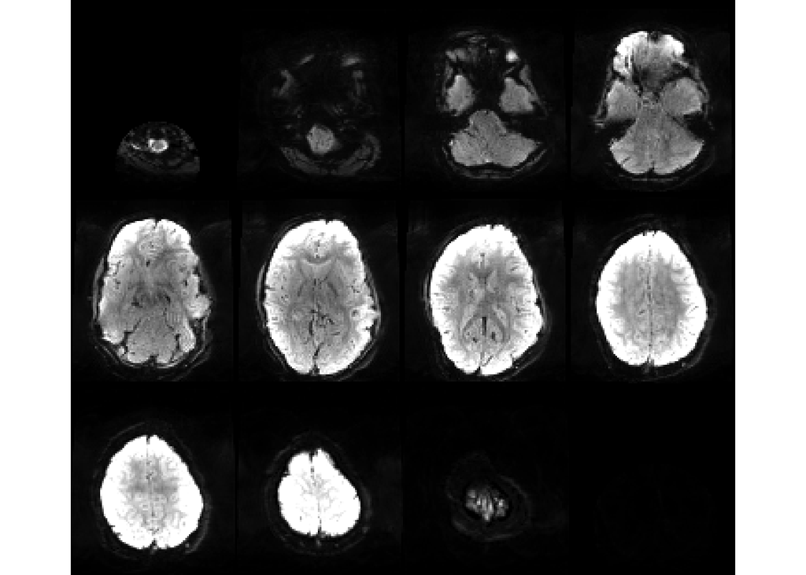

The RL image:

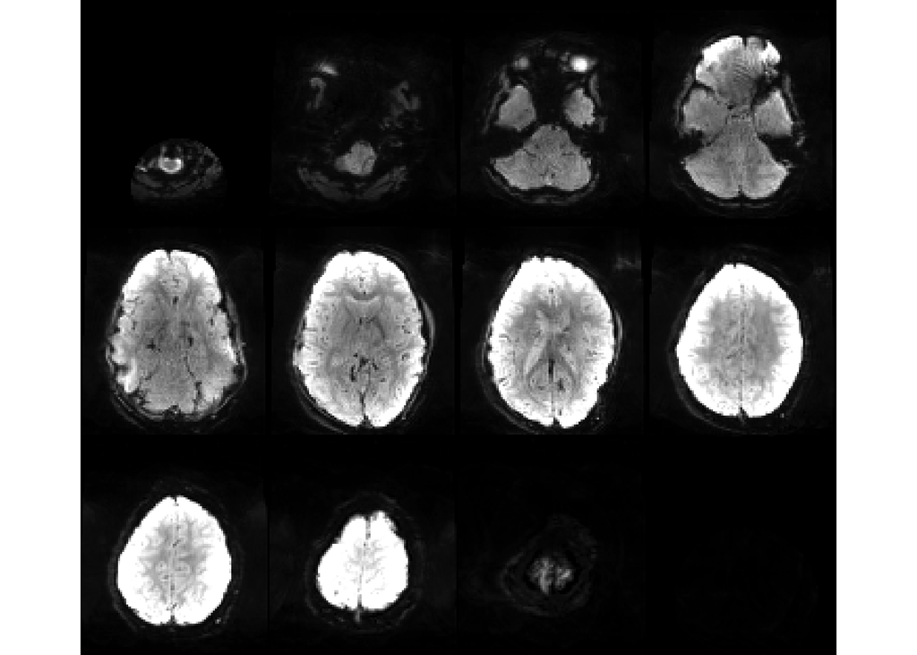

We can average out the distortions in each direction by a template building approach.

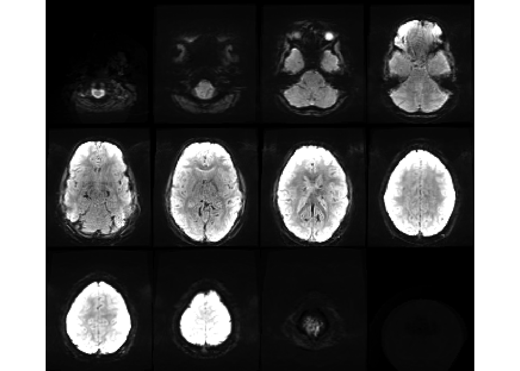

```r
avgLRRL = buildTemplate( boldRL, list( boldRL, boldLR ), 'SyN' )
invisible( plot( avgLRRL, axis=3, nslices=12, doCropping=FALSE ) )
```

Let us see how this maps to T1:

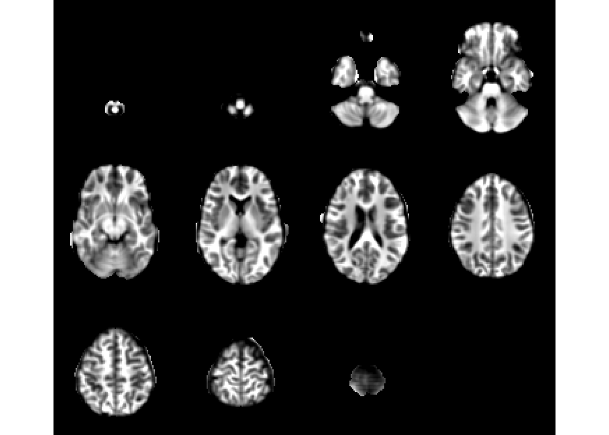

```r
msk = getMask( avgLRRL ) %>% iMath("MD",1)
t1 = antsImageRead( paste0( rdir, '/data/LS2001_3T_T1w_MPR1_2mm.nii.gz' ) ) %>%
  n4BiasFieldCorrection( shrinkFactor = 8 ) %>% n4BiasFieldCorrection( shrinkFactor = 4 )
t1reg = antsRegistration( avgLRRL, t1, 'Rigid' )
invisible( plot( t1reg$warpedmovout * msk, axis=3, nslices=12, doCropping=FALSE ) )
```

Use an edge map to make it easier to compare:

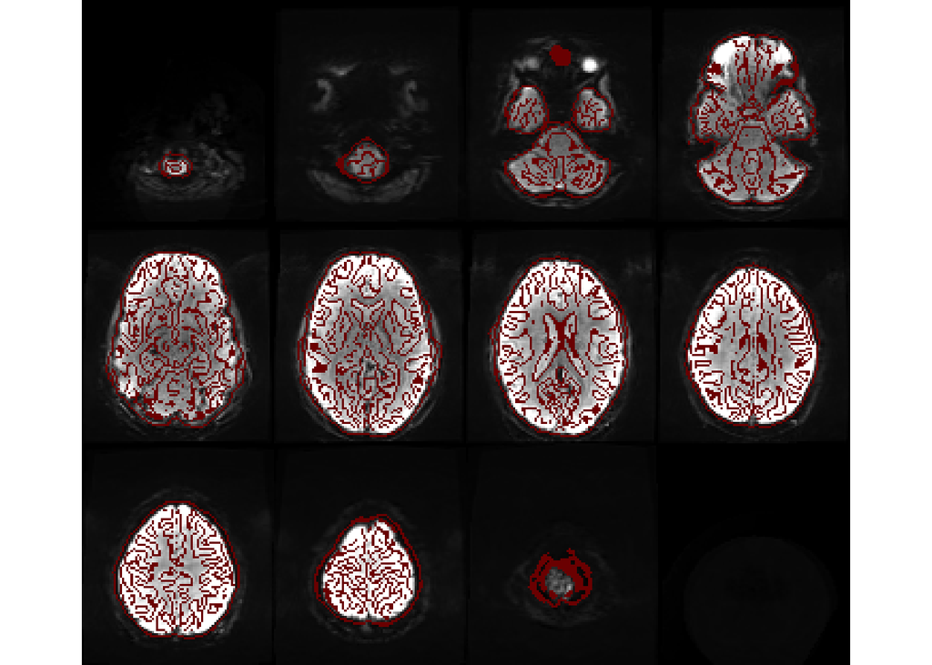

```r
canner = iMath( t1reg$warpedmovout * msk, "Canny", 1, 5, 12  )
invisible( plot( avgLRRL, canner, axis=3, nslices=12, doCropping=FALSE ) )
```

But isnt distortion primarily within plane? Let’s use that prior information.

```r
fix1 = antsRegistration( boldRL, avgLRRL, "SyNOnly", restrictTransformation = c(1,1,0) )
```

Question: Why do we use `boldRL` as the “fixed” image?

Verify by looking at the magnitude of the transformation components.

```r
mywarp = antsImageRead( fix1$invtransforms[2] )
mywarpxyz = splitChannels( mywarp )
print( paste(
  'X-abs-mean:', mean(abs(mywarpxyz[[1]])),
  'Y-abs-mean:', mean(abs(mywarpxyz[[2]])),
  'Z-abs-mean:', mean(abs(mywarpxyz[[3]])) ) )
```

```
## [1] "X-abs-mean: 0.545844292194855 Y-abs-mean: 0.268930736669695 Z-abs-mean: 0"
```

Check the new output which allows deformation only in X and Y:

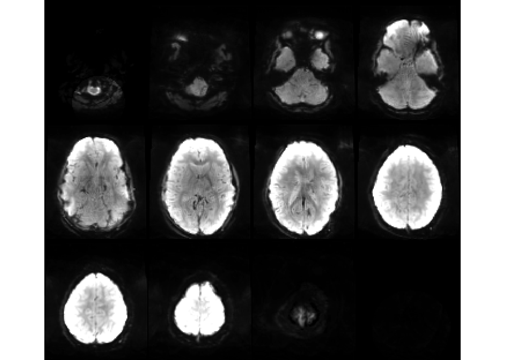

```r
invisible( plot( fix1$warpedfixout, axis=3, nslices=12, doCropping=FALSE ) )
```

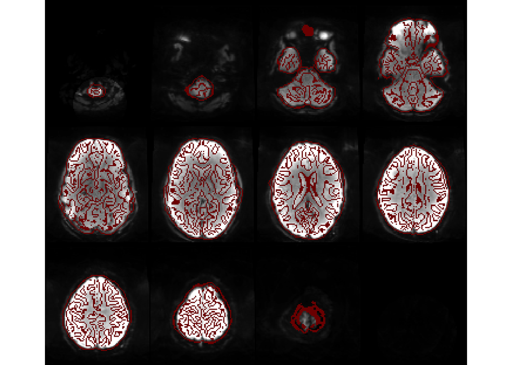

```r
invisible( plot( fix1$warpedfixout, canner, axis=3, nslices=12, doCropping=FALSE ) )
```

Note: `SyNOnly` does not do rigid transformation. One may need to compute a separate rigid transformation first and pass this as an initial transformation to `SyNOnly`.

One can then apply this to the full time series ( data not provided )

```r
rsfMRIfixed = antsApplyTransforms(  avgLRRL,  boldRLts, fix1$invtransforms, imagetype = 3  )
```

This should be evaluated carefully before applying at large scale to new data.

As noted by satra ghosh:

> it may be useful to compare with the topup/applytopup corrected images that HCP provides. i think you may find that the topup fields can be estimated with ants. i have never done this before. the reason the spin echo images are used over the gradient echo bold images is they have less dropout.

> there is also this, which uses syn: [SDC](http://fmriprep.readthedocs.io/en/latest/api/index.html#sdc-fieldmapless)